```r
library(BSgenome)
library(BSgenome.Scerevisiae.UCSC.sacCer2)
library(AnnotationHub)
```

## Views

`Views` are used when you have a single big object (think chromosome or other massive dataset) and you need to deal with (many) subsets of this object.

Technically, a `Views` is like an `IRanges` couple with a pointer to the massive object. The `IRanges` contains the indexes. Let’s look at `matchPattern` again:

```r
library("BSgenome.Scerevisiae.UCSC.sacCer2")
dnaseq <- DNAString("ACGTACGT")
vi <- matchPattern(dnaseq, Scerevisiae$chrI)
vi
```

```
##   Views on a 230208-letter DNAString subject
## subject: CCACACCACACCCACACACCCACACACCACACCA...TGTGTGGGTGTGGTGTGGGTGTGGTGTGTGTGGG
## views:
##     start   end width
## [1] 57932 57939     8 [ACGTACGT]
```

Get the `IRanges` component by

```r
ranges(vi)
```

```
## IRanges object with 1 range and 0 metadata columns:
##           start       end     width
##       <integer> <integer> <integer>
##   [1]     57932     57939         8
```

The `IRanges` gives us indexes into the underlying subject (here chromosome I). To be clear, compare these two:

```r
vi
```

```
##   Views on a 230208-letter DNAString subject
## subject: CCACACCACACCCACACACCCACACACCACACCA...TGTGTGGGTGTGGTGTGGGTGTGGTGTGTGTGGG
## views:
##     start   end width
## [1] 57932 57939     8 [ACGTACGT]
```

```r
Scerevisiae$chrI[ start(vi):end(vi) ]
```

```
##   8-letter "DNAString" instance
## seq: ACGTACGT
```

The `Views` object also look a bit like a `DNAStringSet`:

```r
alphabetFrequency(vi)
```

```
##      A C G T M R W S Y K V H D B N - + .
## [1,] 2 2 2 2 0 0 0 0 0 0 0 0 0 0 0 0 0 0
```

The advantage of `Views` is that they don’t duplicate the sequence information from the subject; all they keep track of are indexes into the subject (stored as `IRanges`). This makes it very (1) fast, (2) low-memory and makes it possible to do things like

```r
shift(vi, 10)
```

```
##   Views on a 230208-letter DNAString subject
## subject: CCACACCACACCCACACACCCACACACCACACCA...TGTGTGGGTGTGGTGTGGGTGTGGTGTGTGTGGG
## views:
##     start   end width
## [1] 57942 57949     8 [AAGCTTTG]
```

where we now get the sequence 10 bases next to the original match. This could not be done if all we had were the bases of the original subsequence.

`Views` are especially powerful when there are many of them. A usecase often occur the set of all exons (or promoters) of all genes in the genome. You can use `GRanges` as `Views` as well. Lets look at the hits from `vmatchPattern`.

```r
gr <- vmatchPattern(dnaseq, Scerevisiae)
gr
```

```
## GRanges object with 170 ranges and 0 metadata columns:
##         seqnames        ranges strand
##            <Rle>     <IRanges>  <Rle>
##     [1]     chrI   57932-57939      +
##     [2]     chrI   57932-57939      -
##     [3]    chrII   49581-49588      +
##     [4]    chrII 411291-411298      +
##     [5]    chrII 491129-491136      +
##     ...      ...           ...    ...
##   [166]   chrXVI 195477-195484      -
##   [167]   chrXVI 683620-683627      -
##   [168]   chrXVI 837296-837303      -
##   [169]   chrXVI 906938-906945      -
##   [170]   chrXVI 943045-943052      -
##   -------
##   seqinfo: 18 sequences from an unspecified genome
```

```r
vi2 <- Views(Scerevisiae, gr)
vi2
```

```
## BSgenomeViews object with 170 views and 0 metadata columns:
##         seqnames        ranges strand            dna
##            <Rle>     <IRanges>  <Rle> <DNAStringSet>
##     [1]     chrI   57932-57939      +     [ACGTACGT]
##     [2]     chrI   57932-57939      -     [ACGTACGT]
##     [3]    chrII   49581-49588      +     [ACGTACGT]
##     [4]    chrII 411291-411298      +     [ACGTACGT]
##     [5]    chrII 491129-491136      +     [ACGTACGT]
##     ...      ...           ...    ...            ...
##   [166]   chrXVI 195477-195484      -     [ACGTACGT]
##   [167]   chrXVI 683620-683627      -     [ACGTACGT]
##   [168]   chrXVI 837296-837303      -     [ACGTACGT]
##   [169]   chrXVI 906938-906945      -     [ACGTACGT]
##   [170]   chrXVI 943045-943052      -     [ACGTACGT]
##   -------
##   seqinfo: 18 sequences (2 circular) from sacCer2 genome
```

First let us get gene coordinates from `Biocpkg("AnnotationHub")`.

```r
ahub <- AnnotationHub()
```

```
## snapshotDate(): 2019-10-29
```

```r
qh <- query(ahub, c("sacCer2", "genes"))
qh
```

```
## AnnotationHub with 2 records
## # snapshotDate(): 2019-10-29
## # $dataprovider: UCSC
## # $species: Saccharomyces cerevisiae
## # $rdataclass: GRanges
## # additional mcols(): taxonomyid, genome, description,
## #   coordinate_1_based, maintainer, rdatadateadded, preparerclass, tags,
## #   rdatapath, sourceurl, sourcetype
## # retrieve records with, e.g., 'object[["AH7048"]]'
##
##            title
##   AH7048 | SGD Genes
##   AH7049 | Ensembl Genes
```

```r
genes <- qh[[which(qh$title == "SGD Genes")]]
```

```
## loading from cache
```

```r
genes
```

```
## GRanges object with 6717 ranges and 5 metadata columns:
##          seqnames        ranges strand |        name     score     itemRgb
##             <Rle>     <IRanges>  <Rle> | <character> <numeric> <character>
##      [1]     chrI 130802-131986      + |     YAL012W         0        <NA>
##      [2]     chrI       335-649      + |     YAL069W         0        <NA>
##      [3]     chrI       538-792      + |   YAL068W-A         0        <NA>
##      [4]     chrI     1807-2169      - |     YAL068C         0        <NA>
##      [5]     chrI     2480-2707      + |   YAL067W-A         0        <NA>
##      ...      ...           ...    ... .         ...       ...         ...
##   [6713]  chrXIII 923492-923800      - |     YMR326C         0        <NA>
##   [6714]  2micron      252-1523      + |      R0010W         0        <NA>
##   [6715]  2micron     1887-3008      - |      R0020C         0        <NA>
##   [6716]  2micron     3271-3816      + |      R0030W         0        <NA>
##   [6717]  2micron     5308-6198      - |      R0040C         0        <NA>
##                  thick        blocks
##              <IRanges> <IRangesList>
##      [1] 130802-131986        1-1185
##      [2]       335-649         1-315
##      [3]       538-792         1-255
##      [4]     1807-2169         1-363
##      [5]     2480-2707         1-228
##      ...           ...           ...
##   [6713] 923492-923800         1-309
##   [6714]      252-1523        1-1272
##   [6715]     1887-3008        1-1122
##   [6716]     3271-3816         1-546
##   [6717]     5308-6198         1-891
##   -------
##   seqinfo: 18 sequences (2 circular) from sacCer2 genome
```

Compute the GC content of all promoters in the yeast genome.

```r
prom <- promoters(genes)
```

```
## Warning in valid.GenomicRanges.seqinfo(x, suggest.trim = TRUE): GRanges object contains 37 out-of-bound ranges located on sequences
##   chrI, chrV, chrX, chrII, chrIV, chrIX, chrVI, chrXI, chrXV, chrIII,
##   chrVII, chrXII, chrXIV, chrXVI, chrVIII, and chrXIII. Note that ranges
##   located on a sequence whose length is unknown (NA) or on a circular
##   sequence are not considered out-of-bound (use seqlengths() and
##   isCircular() to get the lengths and circularity flags of the underlying
##   sequences). You can use trim() to trim these ranges. See
##   ?`trim,GenomicRanges-method` for more information.
```

```r
head(prom, n = 3)
```

```
## GRanges object with 3 ranges and 5 metadata columns:
##       seqnames        ranges strand |        name     score     itemRgb
##          <Rle>     <IRanges>  <Rle> | <character> <numeric> <character>
##   [1]     chrI 128802-131001      + |     YAL012W         0        <NA>
##   [2]     chrI     -1665-534      + |     YAL069W         0        <NA>
##   [3]     chrI     -1462-737      + |   YAL068W-A         0        <NA>
##               thick        blocks
##           <IRanges> <IRangesList>
##   [1] 130802-131986        1-1185
##   [2]       335-649         1-315
##   [3]       538-792         1-255
##   -------
##   seqinfo: 18 sequences (2 circular) from sacCer2 genome
```

We get a `warning` that some of these promoters are out-of-band (see the the second and third element in the `prom` object; they have negative values for their ranges). We clean it up and continue

```r
prom <- trim(prom)
promViews <- Views(Scerevisiae, prom)
gcProm <- letterFrequency(promViews, "GC", as.prob = TRUE)
head(gcProm)
```

```
##            G|C
## [1,] 0.4668182
## [2,] 0.4868914
## [3,] 0.4572592
## [4,] 0.3731818
## [5,] 0.3859091
## [6,] 0.3309091
```

Previously, we computed the GC content of the yeast genome using `Biostrings`. Let us do it again, briefly

```r
params <- new("BSParams", X = Scerevisiae, FUN = letterFrequency, simplify = TRUE)
gccontent <- bsapply(params, letters = "GC")
gcPercentage <- sum(gccontent) / sum(seqlengths(Scerevisiae))
gcPercentage
```

```
## [1] 0.3814872
```

Let us compare this genome percentage to the distribution of GC content for promoters

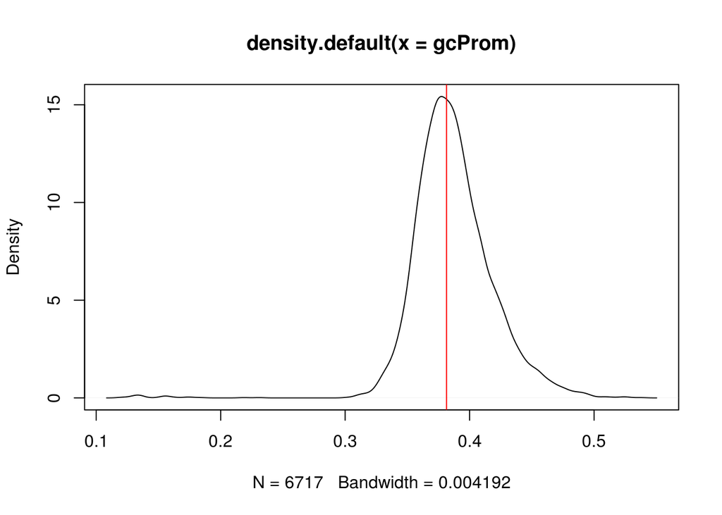

```r
plot(density(gcProm))
abline(v = gcPercentage, col = "red")
```

At first glance, the GC content of the promoters is not very different from the genome-wide GC content (perhaps shifted a bit to the right).